# Deblender footprints

For the Rubin Science Platform at data.lsst.cloud.  
Data Release: [Data Preview 2](https://dp2.lsst.io/)  
Container Size: Large  
LSST Science Pipelines version: v30.0.11  
Last verified to run: 2026-10-23  
Repository: github.com/lsst/tutorial-notebooks  
DOI: 10.11578/rubin/dc.20250909.20

**Learning objective:** This notebook demonstrates how to use the deblended models generated by scarlet lite.

**LSST data products:** `Object` table, `deep_coadd`, `object_scarlet_models`

**Packages:** `lsst.rsp`, `lsst.daf.butler`, `lsst.scarlet.lite`, `lsst.meas.extensions.scarlet`

**Credit:** Originally developed by the Rubin Community Science team. Please consider acknowledging them if this notebook is used for the preparation of journal articles, software releases, or other notebooks. The deblender packages are based on [Melchior et al. 2018](https://ui.adsabs.harvard.edu/abs/2018A%26C....24..129M/abstract), and the [Scarlet software](https://pmelchior.github.io/scarlet/) written by Peter Melchior and Fred Moolekamp. Further documentation on Scarlet is available at that site.

**Get Support:** Everyone is encouraged to ask questions or raise issues in the [Support Category](https://community.lsst.org/c/support) of the Rubin Community Forum. Rubin staff will respond to all questions posted there.

## 1. Introduction

This notebook demonstrates how to reconstruct per-pixel models of objects that are deblended by the LSST Science Pipeline when building the `object` table. The focus is on how to recover the model of an object from its information in the `object` catalog, and how to investigate the blend as a whole.

To measure the photometry of objects in `deep_coadd` images, the LSST Science Pipeline uses the multi-band deblending scarlet algorithm [Melchior et al. 2018](https://ui.adsabs.harvard.edu/abs/2018A%26C....24..129M/abstract) implemented with optimizations for LSST data in [Scarlet Lite](https://github.com/lsst/scarlet_lite). The algorithm models objects in a blend as a collection of components that have the same spectrum in each pixel of their morphology, assuming that flux monotonically decreases from the peak (maximum pixel value) of the component.

This tutorial will begin with the coordinates of an object of interest and show how to obtain its model and the model of the other sources that are extracted from the same blend.

**Note**: There have been updates to the deblending implementation since DP1 so *expect the API to be slightly different (improved) in future data releases*, including having more information available to understand how blended an object is with its neighbors and useful cuts to remove potentially more difficult blends from analysis.

**References:**

- A general discussion of blending impacts to LSST can be found in this article titled "[The challenge of blending in large sky surveys](https://lss.fnal.gov/archive/2021/pub/fermilab-pub-21-598-ppd.pdf)" by Melchior et al. 2021.
- Some more in-depth presentations on the deblending implementation in the LSST Science Pipeline are available from recorded talks during the Rubin Project and Community Workshop 2022's session on "[Deblending Plans and Challenges](https://project.lsst.org/meetings/rubin2022/agenda/deblending-plans-and-challenges)".
- Further information about the available deblending flags, and the processes that produce the deblender data products discussed in this tutorial can be found in this [overview of the deblending flags](https://pipelines.lsst.io/modules/lsst.pipe.tasks/deblending-flags-overview.html).

**Related tutorials:** A notebook introducing the deblender data products stored in the `Object` table is available as 206.1 Introduction to deblender outputs. A notebook introducing image subsets and defining bounding boxes is available as 104.5 titled Image subsets with the butler.

### 1.1. Import packages

The [matplotlib](https://matplotlib.org/), [numpy](http://www.numpy.org/), and [astropy](http://www.astropy.org/) libraries are widely used Python libraries for plotting, scientific computing, and astronomical data analysis.

`lsst.afw.image` provides access to some of the extended products created by the deblender pipeline. The `lsst.afw.display` and `lsst.images` libraries provides access to image visualization routines and the `lsst.daf.butler` library is used to access data products via the butler. The `RSPDiscovery` class in the `lsst.rsp` package is for accessing the TAP service. Finally, `lsst.scarlet` and `lsst.meas.extensions.scarlet` are two packages containing the scarlet software infrastructure, to enable displaying and analyzing deblended models and object footprints.

```python
import numpy as np
import matplotlib
import matplotlib.pyplot as plt

from astropy.coordinates import SkyCoord
from astropy.visualization import ZScaleInterval

from lsst.daf.butler import Butler
from lsst.afw.image import MultibandExposure
import lsst.afw.display as afw_display
from lsst.images import Box, Interval
from lsst.rsp import RSPDiscovery

import lsst.scarlet.lite as scl
import lsst.meas.extensions.scarlet as mes
```

### 1.2. Define parameters

Set matplotlib parameters to define the lower left corner of images as the origin.

```python
matplotlib.rcParams['image.origin'] = 'lower'
```

Set the backend for afwDisplay to matplotlib.

```python
afw_display.setDefaultBackend('matplotlib')
```

Get an instance of the TAP service.

```python
discovery = RSPDiscovery("dp2")
service = discovery.get_tap_client()
```

Instantiate the butler.

```python
butler = Butler('dp2', collections=["dp2"])
assert butler is not None
```

## 2. Identify a blend

First, identify a blended system in the DP2 data. This example will load data for the deblended object that is located at `(151.78888574607532, 1.55284113175051)` along with the relevant fields required to access the blend models associated with it.

- **tract**: the LSST track that contains the object
- **patch**: the patch in the `tract` that contains the object
- **parentObjectId**: the unique ID of the object's parent blend
- **deblend_blendId**: the index of the sub-blend inside the parent blend
- **deblend_blendNChild**: Describes the number of children that were in the parent blend
- **deblend_peak_center_x,y**: Not required but will be used later to mark the location of the object

### 2.1. Query for deblended object

Search for all objects within 1 arcsec of the object of interest. There should only be a single result.

```python
ra = 151.78888574607532
dec = 1.55284113175051

query = f"""SELECT objectId, coord_ra, coord_dec, parentObjectId,
            deblend_blendId, tract, patch,
            deblend_blendNChild, deblend_peak_center_x, deblend_peak_center_y
            FROM dp2.Object
            WHERE CONTAINS(POINT('ICRS', coord_ra, coord_dec),
            CIRCLE('ICRS', {ra}, {dec}, 0.000278)) = 1"""

job = service.submit_job(query)
job.run()
job.wait(phases=['COMPLETED', 'ERROR'])
if job.phase == 'ERROR':
    job.raise_if_error()

results = job.fetch_result().to_table()
print(len(results))
```

```
1
```

Identify the parent object from which the target was deblended (using `parentObjectId` from the object catalog) and identify all the deblended `children`. This parent object was deblended into 11 separate objects.

```python
parentId = results['parentObjectId'][0]

query = f"""SELECT objectId, coord_ra, coord_dec, parentObjectId, footprintArea,
            deblend_peak_center_x, deblend_peak_center_y
            FROM dp2.Object
            WHERE CONTAINS(POINT('ICRS', coord_ra, coord_dec ),
            CIRCLE('ICRS',  {ra}, {dec},  .1)) = 1
            AND parentObjectId = {parentId}"""


job = service.submit_job(query)
job.run()
job.wait(phases=['COMPLETED', 'ERROR'])
print('Job phase is', job.phase)

assert job.phase == 'COMPLETED'
children = job.fetch_result().to_table()
children
```

```
Job phase is COMPLETED
```

*Table length=11*

| objectId int64 | coord_ra deg float64 | coord_dec deg float64 | parentObjectId int64 | footprintArea pix int32 | deblend_peak_center_x pix int32 | deblend_peak_center_y pix int32 |
| --- | --- | --- | --- | --- | --- | --- |
| 788017509725927499 | 151.7876581354054 | 1.5520202792623203 | 788017509725899960 | 1103 | 14061 | 2769 |
| 788017509725927503 | 151.78799725447507 | 1.5541580723790012 | 788017509725899960 | 648 | 14055 | 2808 |
| 788017509725927502 | 151.78940061329126 | 1.5513401386815453 | 788017509725899960 | 879 | 14030 | 2757 |
| 788017509725927501 | 151.7873381242345 | 1.5527339536780616 | 788017509725899960 | 1025 | 14067 | 2782 |
| 788017509725927500 | 151.78783048296668 | 1.5526027394298354 | 788017509725899960 | 1228 | 14058 | 2780 |
| 788017509725927498 | 151.78830479725625 | 1.5537066759440619 | 788017509725899960 | 1081 | 14049 | 2800 |
| 788017509725927497 | 151.78888574607532 | 1.55284113175051 | 788017509725899960 | 1588 | 14039 | 2784 |
| 788017509725927496 | 151.7888307832984 | 1.5518285256916162 | 788017509725899960 | 1647 | 14040 | 2766 |
| 788017509725927495 | 151.78923138010427 | 1.5490635184869188 | 788017509725899960 | 804 | 14033 | 2716 |
| 788017509725927494 | 151.78887003102082 | 1.5501733885410403 | 788017509725899960 | 1096 | 14039 | 2736 |
| 788017509725927493 | 151.78821708813376 | 1.549245434908877 | 788017509725899960 | 1156 | 14051 | 2720 |

### 2.2. Visualize the blend

To visualize the blend, plot a `deep_coadd` image subset that contains the blend with children identified. First, retrieve the patch and tract for the coadd containing the blend, and set the band to be i-band.

Next, define the dimensions of the image subset to be 5x the square root of the total `footprintArea` of the blend, in arcseconds. Since `footprintArea` is in pixels, multiply by the pixel scale 0.2 arcsec / pixel to define an appropriate area for the cutout in arcsec.

```python
total_footprint_area = np.sum(children['footprintArea'])
cutoutSideLength = 5.0 * np.sqrt(total_footprint_area) * 0.2

coadd = butler.get("deep_coadd", tract=results['tract'][0], patch=results['patch'][0], band='i')
```

Define the center to be at the deblended target, and define the bounding box to construct the image subset.

```python
center = SkyCoord(ra, dec, unit='deg')
xy = coadd.sky_projection.sky_to_pixel(center)
bbox = Box.factory[round(xy.y):round(xy.y)+1, round(xy.x):round(xy.x)+1].padded(cutoutSideLength)
subset = coadd[bbox]
```

Finally, visualize the blend and its child objects. First display the cutout, and then over plot circles to identify the child objects that were deblended.

[figure not shown]

```python
display = afw_display.Display(frame=1)
display.scale('asinh', 'zscale')

display.mtv(subset.image)
with display.Buffering():
    for ci in range(len(children)):
        display.dot('o', children['deblend_peak_center_x'][ci],
                    children['deblend_peak_center_y'][ci], size=10)
plt.gca().axis('off')
display.show_colorbar(False)

plt.show()
```

> **Figure 1:** The image subset of the i-band `deep_coadd` image displayed in greyscale, with green circles marking the deblended children.

## 3. Blend and object models

Scarlet Lite uses the multi-wavelength images to identify peaks. The scarlet models produced during deblending are available as a data product via the `object_scarlet_model` catalog. This contains all of the information needed to reconstruct the multi-band model for each source.

### 3.1. Load parent blend data

Scarlet lite models are stored in a zip archive with keys for metadata and each blend, allowing efficient retrieval of data for a single parent blend.

Below, find the `object_scarlet_model` data product in the butler by searching for all dataset types with the word "scarlet" in the name.

```python
for dt in sorted(butler.registry.queryDatasetTypes('*scarlet*')):
    print(dt)
```

```
DatasetType('object_scarlet_models', {skymap, tract, patch}, LsstScarletModelData)
```

Use the butler to retrieve the `object_scarlet_models` data product that corresponds to the image that contains this blend.

```python
obj = results[0]

model_data = butler.get(
    "object_scarlet_models",
    tract=obj["tract"],
    patch=obj["patch"],
    parameters={"blend_id": [obj["parentObjectId"]]}
)
```

### 3.2. Extracting the blend data

In DP2, all blends use the same model PSF (a Gaussian with sigma=0.8) and the same observed PSF (the PSF at the center of the patch), and the same bands (usually all bands, `ugrizy`, except on the edges of the survey or crowded fields where not all bands successfully processed). Their models can thus be extracted directly from the metadata (new in DP2). `LsstScarletModelData` is a container for all of the blends in a patch. Omitting the `parameters={"blend_id": [obj["parentObjectId"]]}` in the command above would load all of the models.

`model_data` (above) only loaded a single blend, but it is still returned from the Butler in the full container, which is needed because it contains the metadata required to reconstruct the scarlet lite `Blend` object.

Below, extract the `model_psf`, `psf`, and the bands in the blend. The LSST science pipelines use persistable dataclass objects as intermediaries between the storage containers and python classes. In the case of Scarlet Lite blends, this is the `ScarletBlendData` class. Some attributes of the blend model can be retrieved from `model_data`.

In order to reconstruct the blend, the model PSF from the deconvolved model space is also required. The model PSF is the same for all blends, so extract that here.

Also extract the set of blends associated with this `parentObjectId`.

```python
model_psf = model_data.metadata["model_psf"]
psf = model_data.metadata["psf"]
bands = model_data.metadata["bands"]
```

Print the `bands` metadata associated with the blend model.

```python
print(bands)
```

```
['g', 'i', 'r', 'u', 'y', 'z']
```

Below, extract the parent data from `model_data`. `parent_data` holds the full blend from the `object_detection` catalog. Then, extract the blend data from `parent_data`. `blend_data` holds the deconvolved blend of the object. A model can be extracted for each deblended child from the parent blend.

Multiple parent IDs can also be passed in the list in order to load multiple blends.

```python
parent_data = model_data.blends[obj["parentObjectId"]]

blend_data = parent_data.children[obj["deblend_blendId"]]
```

Finally, convert the `blend_data` storage class into a scarlet lite `Blend` instance called `blend`. The `minimal_data_to_blend` method is used to access the blend model.

```python
blend = blend_data.minimal_data_to_blend(model_psf[None], psf, bands)
```

Print the object IDs for all of the objects in the blend by looking at `Blend.sources`. Notice that the target object is the second one in the list.

```python
for source in blend.sources:
    print(source.metadata["id"])
```

```
788017509725927496
788017509725927497
788017509725927498
788017509725927499
788017509725927500
788017509725927501
788017509725927502
788017509725927503
```

### 3.3. Plot the blend model

#### 3.3.1. Extracting a model

To compare the extracted blend model to observations, first convolve it with the difference kernel so that it matches the observed seeing. This happens automatically when passing `convolve=True` to `Blend.get_model`.

```python
model = blend.get_model(convolve=True)
```

#### 3.3.2. Index slicing

It is useful to be able to change the order of the filters stored in the blend model.

Print the observed bands used in the deblending process. Notice that the observed bands are not in wavelength order, and they are still in the same order from `model_data.bands` above. This is because the LSST science pipelines process each band in alphabetical order, not wavelength order.

```python
print(blend.observation.bands)
```

```
('g', 'i', 'r', 'u', 'y', 'z')
```

All of the band-dependent scarlet lite data products can be re-ordered using indexing by passing slices or tuples of bands, similar to numpy arrays, with the exception that the last band in the slice is *included* in the resulting sliced model.

```python
blend = blend[tuple("ugrizy")]
print(blend.observation.bands)
print(blend["g":"i"].observation.bands)
print(blend["z"].observation.bands)
```

```
('u', 'g', 'r', 'i', 'z', 'y')
('g', 'r', 'i')
('z',)
```

To change to wavelength order, specify `model[tuple("ugrizy")]` or `blend[tuple("ugrizy")]` when retrieving the blend model to display the image with the expected color assignment. If fewer bands of coverage exist, simply replace this by the combination of observed bands, e.g. `tuple("griz")`.

Demonstrate the new filter order below.

```python
print(blend.observation.bands)
```

```
('u', 'g', 'r', 'i', 'z', 'y')
```

#### 3.3.3. Visualize

```python
stretch = 50
Q = 10
norm = scl.display.AsinhMapping(minimum=0, stretch=stretch, Q=Q)
```

By default, Scarlet Lite assumes the input filters are in wavelength order, and thus mapping into an RGB scaling where the first filter map to blue and last filter map to red. This relative weighting between filters to RGB can be altered with the `channel_map` keyword to `img_to_rgb` (see documentation [here](https://pmelchior.github.io/scarlet/tutorials/display.html)).

Below, convert the blend model into an RGB image and display it, and mark the object of interest with an x. (Scarlet lite also has helper functions to display a full blend, mark the location of peaks, show the residuals automatically. This will be demonstrated in Section 4.3).

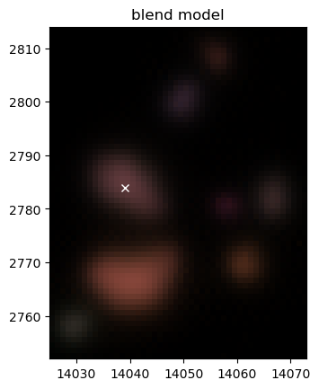

```python
extent = scl.display.get_extent(model.bbox)
rgb = scl.display.img_to_rgb(model, norm=norm)
plt.imshow(rgb, extent=extent)
plt.title("blend model")
plt.plot(obj["deblend_peak_center_x"], obj["deblend_peak_center_y"], "wx")
plt.show()
```

> **Figure 2:** A `ugrizy` RGB color image of the blend model. The original target object from Section 2 is marked with a white x. By default, Scarlet Lite maps the filters into an RGB scaling where the first bands contribute to the blue color and last bands contribute to red.

### 3.4. Displaying a single source model

To display the model for the object, first extract the object from the blend.

```python
source = next((src for src in blend.sources if
    src.metadata["id"] == obj["objectId"]), None)
print(source)
```

```
Source<1>
```

Recall that the object model is in the deconvolved space, so displaying it will show the internal scarlet lite model (intrinsic model) for the object.

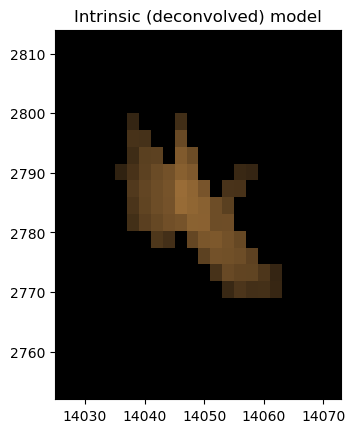

```python
rgb = scl.display.img_to_rgb(source.get_model(), norm=norm)
plt.imshow(rgb, extent=extent)
plt.title("Intrinsic (deconvolved) model")
plt.show()
```

> **Figure 3:** An RGB (PSF-deconvolved) image of the initial deblended source of interest.

Now, to view the model as directly comparable to the data, first convolve it with the observation using the `convolve` method.

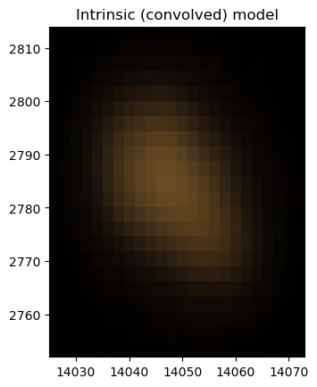

```python
model = blend.observation.convolve(source.get_model())
rgb = scl.display.img_to_rgb(model, norm=norm)
plt.imshow(rgb, extent=extent)
plt.title("Intrinsic (convolved) model")
plt.show()
```

> **Figure 4:** An RGB image of the model of the same initial deblended source in Figure 3, but now convolved with the PSF.

## 4. Compare to observation

This section will make visual comparisons between the blend model and the observed data, and demonstrate some of the Scarlet Lite functionality.

### 4.1. Loading a MultibandExposure

First, load a multi-band exposure for the region that covers the blend. To load the observation, the following information is required: 1) the `tract` and `patch` that defines the region of the sky imaged in the `deep_coadd`; 2) the bounding box of the parent blend (`bbox`), which allows extraction a smaller region from the full `deep_coadd`; and 3) the bands desired for display.

```python
bbox = mes.utils.scarletBoxToBBox(blend.observation.bbox)

mCoadd = MultibandExposure.fromButler(
    butler,
    bands,
    "deep_coadd",
    tract=obj["tract"],
    patch=obj["patch"],
    storageClass="ExposureF",
    parameters={'bbox': bbox}
)
```

### 4.2. Build a full Blend with an Observation

To compare the Scarlet Lite deblended models with the observed data, first create an `observation` object of the `Observation` class. This bundles the actual images in each band (`mCoadd`) with the telescope's PSF (`modelPsf`). Scarlet Lite uses this to convolve the intrinsic model of the blend for comparison to the observed images.

```python
observation = mes.utils.buildObservation(
    modelPsf=model_psf,
    psfCenter=bbox.getCenter(),
    mExposure=mCoadd,
)
```

Pass `observation` into the `blend_data`, to build `full_blend`, which is an instance of the `scarlet.lite.Blend` class that contains all this information together. This enables both the model and real observations to be compared directly using Scarlet Lite's built-in `show_scene` function.

```python
observed_bands = tuple("ugrizy")
full_blend = blend_data.to_blend(observation)[observed_bands]
```

### 4.3. Display full blend residuals

Now, use the Scarlet Lite built in display function called `show_scene` to show the image, blend model, convolved blend model, and residuals between the model and observation.

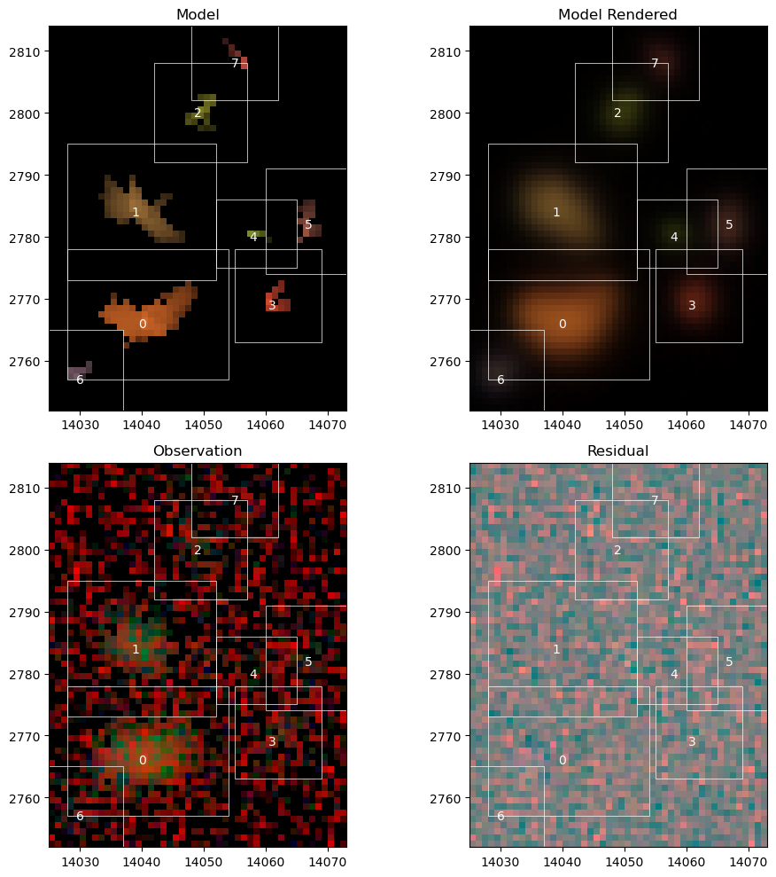

```python
scl.display.show_scene(
    full_blend,
    norm=norm,
    show_model=True,
    show_rendered=True,
    show_observed=True,
    show_residual=True,
    linear=False,
    add_boxes=True,
    add_labels=True,
    figsize=(10, 10),
)

plt.show()
```

> **Figure 5:** Visualization of the model generated by Scarlet Lite, with x and y axes indicating pixel number from the patch/tract. The panels show the blend model (not PSF-convolved; top left), the blend model rendered (PSF-convolved; top right), the observation (bottom left) and the residual image (observation - model rendered; bottom right). All deblended sources are identified with white boxes and a number indicating its ID within the set of deblended objects.

### 4.4. Display source models

Now, use the Scarlet Lite built-in display function called `show_sources` to display the models of the individual sources compared to the observed image and its spectral energy distribution.

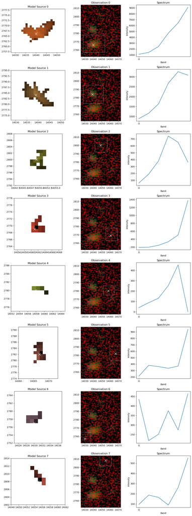

```python
scl.display.show_sources(
    full_blend,
    norm=norm,
    show_observed=True,
    add_boxes=True
)
plt.show()
```

> **Figure 6:** Visualization of the individual deblended sources (top to bottom show ID 0 to 7). For each source, left panel shows the PSF-deconvolved model footprint (where the color scale corresponds to the weighted RGB color), middle panel shows the observation of the blend with the source identified by a white box, and right panel shows the flux in each band. The bands are shown all 6 LSST bands, and are in order of increasing wavelength, defined in `observed_bands`. The units of intensity is nJy, as in the image (nJy/pixel).

### 4.5. Display the measurement models

In the LSST science pipeline, the final properties saved in the Object catalog are not measured on the idealized Scarlet models directly. Instead, the pipeline uses the Scarlet models as templates to determine what fraction of light in each pixel belongs to which object. The algorithm uses these fractions to redistribute the raw image flux, creating an isolated, flux-conserved image for each source. Finally, the pipeline runs its standard measurement tools on these isolated images to calculate the object's centroid position, total flux, and shape.

The first step is to conserve the flux by applying `conserve_flux()` to modify the `full_blend` object. Doing so will create a `Source.flux_weighted_image` for each `Source` in the `full_blend`, and save those internally.

```python
full_blend.conserve_flux()
```

Now, pass `use_flux=True` to `show_sources` to see the flux weighted models (left panel) that were used in all of the measurement tasks. Notice that the `spectrum` in Figure 7 is now also different from in Figure 6. This is because Figure 7 is based on the summing the flux from each band the real images rather than based on the idealized models.

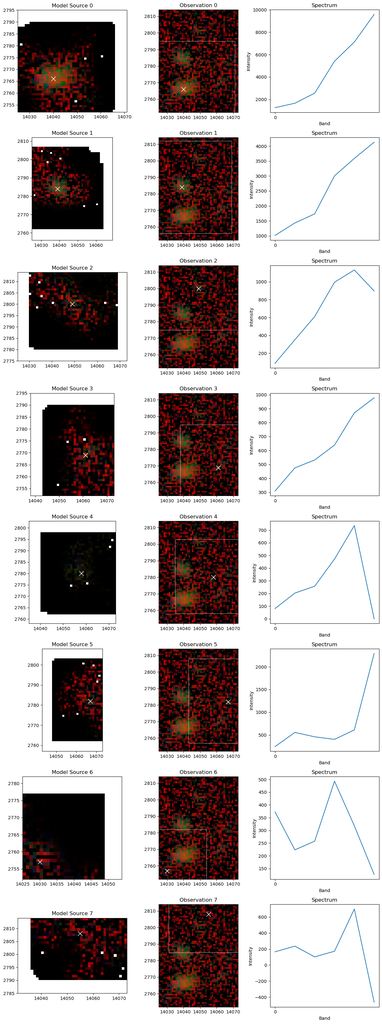

```python
scl.display.show_sources(
    full_blend,
    norm=norm,
    show_observed=True,
    add_boxes=True,
    use_flux=True,
)
plt.show()
```

## 5. Analyzing a single object

```python
object1 = full_blend.sources[1]
print(object1.metadata["id"])
```

```
788017509725927497
```

As in Section 4.5, conserve the flux of the overall scene.

```python
full_blend.conserve_flux()
```

Three different models for the object are available for inspection. 1) The deconvolved scarlet model; 2) the convolution of the scarlet model with the difference kernel; and 3) the flux-redistributed model that the science pipelines use for measurement. The section demonstrates how to plot these three different models for source 1 in the blend.

First, extract the deconvolved model from the object. The output is a Scarlet Lite image.

```python
source_model = object1.get_model()
display_bands = tuple("griz")
```

Next, project the model into a box large enough to fit the convolved model.

```python
psf_radius = int((np.max(blend.observation.psfs.shape)+1)//2)
enlarged_box = source_model.bbox.grow(psf_radius)
convolved_model = source_model.copy().project(bbox=enlarged_box)
```

Finally, plot the three models for the object for inspection.

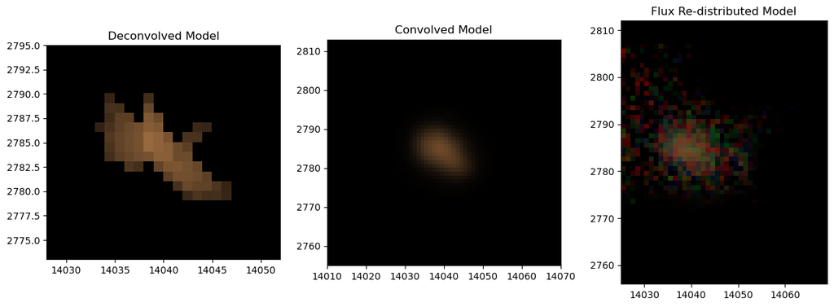

```python
fig, ax = plt.subplots(1, 3, figsize=(15, 5))

extent = scl.display.get_extent(object1.bbox)
rgb = scl.display.img_to_rgb(source_model[display_bands], norm=norm)
ax[0].imshow(rgb, origin='lower', extent=extent)
ax[0].set_title("Deconvolved Model")

convolved_model = blend.observation.convolve(convolved_model)
extent = scl.display.get_extent(enlarged_box)
rgb = scl.display.img_to_rgb(convolved_model[display_bands], norm=norm)
ax[1].imshow(rgb, origin='lower', extent=extent)
ax[1].set_title("Convolved Model")

flux_model = object1.flux_weighted_image
extent = scl.display.get_extent(flux_model.bbox)
rgb = scl.display.img_to_rgb(flux_model[display_bands], norm=norm)
ax[2].imshow(rgb, origin='lower', extent=extent)
ax[2].set_title("Flux Re-distributed Model")

plt.show()
```

> **Figure 8:** Visualization of deblended source 1. Left panel shows the PSF-deconvolved model footprint (where the color scale corresponds to the weighted RGB color), middle panel shows the convolution of the scarlet model with the difference kernel and right panel shows the flux-redistributed model that the science pipelines use for measurements.